# Web_scrapper

## Step 3: Cleaning Our Data

Under this section, we will perform the following checks on our dataset:

1. Missing Values: We will identify and handle any missing values in our dataset. Missing values can occur when data is not recorded or unavailable for certain observations. We need to address these missing values appropriately to ensure the integrity of our analysis.
2. Outliers: Outliers are data points that significantly deviate from the rest of the dataset. They can impact the accuracy and reliability of our analysis. We will identify and handle outliers by applying suitable techniques such as statistical methods or domain knowledge.
3. Structural Errors: Structural errors refer to inconsistencies or errors in the structure or format of our data. These errors can include incorrect data types, inconsistent naming conventions, or incompatible formats. We will identify and rectify these structural errors to ensure the consistency and quality of our dataset.

#### a. Checking for nulls

```python
jumia_offers.isnull().sum()
#Our dataset has no missing values.
```

```
Name        0
Brand       0
Category    0
Shipping    0
Price       0
Offer       0
Discount    0
dtype: int64
```

#### b. Plotting for outliers

We will utilize scatter plots and baxplots to check for outliers in the price and offer columns

```python
import seaborn
import matplotlib
%matplotlib inline
```

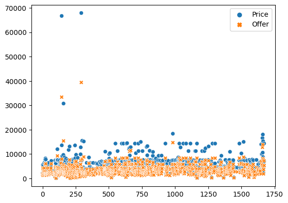

```python
#Scatterplot1
seaborn.scatterplot(data=jumia_offers[['Price','Offer']])
```

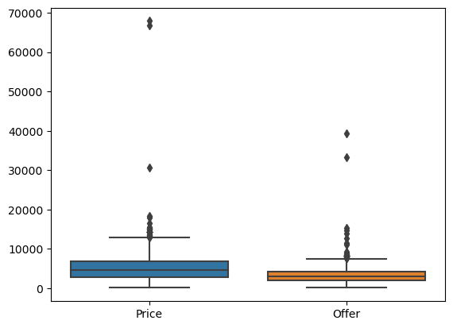

```python
#Boxplot1
seaborn.boxplot(data=jumia_offers[['Price','Offer']])
```

From the two plots above, we can tell that the two numerical columns (price & offer) contain outliers.

#### C. Cleaning Outliers

Under this section, we will utilize the standard deviation technique to remove outliers from our data.

```python
#Creating a custom function to check and filter out outliers from a given column
'''Our function calculates the series mean and standard deviation then uses them to set the upper and lower bounds in our data.
In this case we utilize '3 standard deviations' from the mean on both bounds.'''
def std_outlier(df):
    avg=df.mean()
    std=df.std()
    upper_limit=avg+(3*std)
    lower_limit=avg-(3*std)
    clean_data=df[(df>lower_limit) & (df<upper_limit)]
    return clean_data
```

```python
clean_price=std_outlier(jumia_offers['Price'])

clean_offer=std_outlier(jumia_offers['Offer'])

#Running this cell once removes the least amount of outliers possible.
# If you want to increase the accuracy of 'cleaning' your data, you should run the cell multiple times.
# Check the boxplots and scatter plots below to verify the changes in your dataset
```

```python
#Inserting the clean price and Offer values into our dataset
jumia_offers['Price']=clean_price
jumia_offers['Offer']=clean_offer
```

```python
# Checking for entries whose values have been flagged as outliers.
jumia_offers[(jumia_offers['Price'].isnull()) | (jumia_offers['Offer'].isnull())]
```

|  | Name | Brand | Category | Shipping | Price | Offer | Discount |
| --- | --- | --- | --- | --- | --- | --- | --- |
| 144 | 【Free Shipping + Super Deal + Limited Offer】Di... | Generic | Automobile/Motorcycle & Powersports/Fluids & M... | Shipped from abroad | NaN | NaN | 50 |
| 158 | 3x2m/3x3m Thickness 0.5mm Pond Liner Special O... | Generic | Garden & Outdoors/Gardening & Lawn Care/Water ... | Shipped from abroad | NaN | NaN | 50 |
| 292 | SVCI 6154A VA-Auto Diagnositc Tool Support CAN... | Generic | Home & Office/Tools & Home Improvement/Measuri... | Shipped from abroad | NaN | NaN | 42 |
| 665 | Great Offer New Thermal Underwear | Fashion | Fashion/Men's Fashion/Clothing/Underwear | Shipped from abroad | 12810.0 | NaN | 11 |
| 983 | Special Offer 100% Guarantee Soft Natural Cow ... | Fashion | Fashion/Luggage & Travel Gear/Briefcases | Shipped from abroad | 18338.0 | NaN | 20 |
| 1659 | Buddha Utensils Special F Offer Temple Ornamen... | Generic | Home & Office/Home & Kitchen/Kitchen & Dining/... | Shipped from abroad | 16568.0 | NaN | 23 |
| 1662 | 10pcs Tibet Tibetan F Buddhist Offering Copper... | Generic | Home & Office/Home & Kitchen/Home Decor/Home D... | Shipped from abroad | 17992.0 | NaN | 23 |

```python
# Checking to see if the two columns have introduced any nulls in our dataset.
jumia_offers.isnull().sum()
```

```
Name        0
Brand       0
Category    0
Shipping    0
Price       3
Offer       7
Discount    0
dtype: int64
```

```python
# Estimating the percentage of missing values
total_observations=np.product(jumia_offers.shape)
missing_observations=jumia_offers.isnull().sum().sum()
Null_ppercentage=(missing_observations/total_observations)*100
Null_ppercentage
#This percentage informs us on the technique to be used when handling nulls.
```

```
0.17857142857142858
```

#### d. Handling Missing values

This percentage will vary depending on how many times you ran the outlier removal function.

If the percentage is significant, consider handling your missing values differently by filling them with column averages.

```python
# Lets create another copy of our data set containing null values for future reference
clean_data=jumia_offers.copy()
```

```python
# Dropping null values in our new dataset
clean_data.dropna(inplace=True)
```

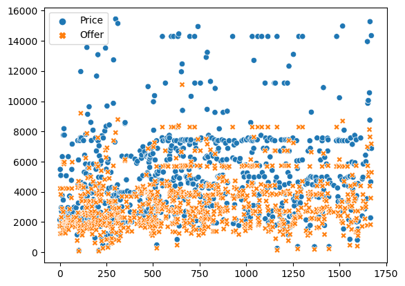

```python
seaborn.scatterplot(data=clean_data[['Price','Offer']])
```

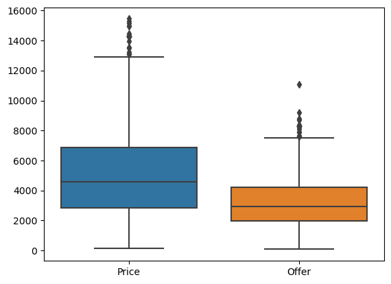

```python
seaborn.boxplot(data=clean_data[['Price','Offer']])
```

```python
clean_data.info()
```

```
<class 'pandas.core.frame.DataFrame'>
Int64Index: 793 entries, 0 to 1672
Data columns (total 7 columns):
 #   Column    Non-Null Count  Dtype
---  ------    --------------  -----
 0   Name      793 non-null    object
 1   Brand     793 non-null    object
 2   Category  793 non-null    object
 3   Shipping  793 non-null    object
 4   Price     793 non-null    float64
 5   Offer     793 non-null    float64
 6   Discount  793 non-null    int64
dtypes: float64(2), int64(1), object(4)
memory usage: 49.6+ KB
```

#### e. Fixing Structural errors in strings

In this section we will clean our dataset by fixing structural/format issues in columns containing string values.

```python
clean_data[['Name','Category']].tail()
```

|  | Name | Category |
| --- | --- | --- |
| 1664 | Kitchen Faucet with Pull Down Sprayer Faucet O... | Home & Office/Tools & Home Improvement/Kitchen... |
| 1667 | New Offers USB Flash Drive 8GB | Computing/Computers & Accessories/Data Storage... |
| 1668 | Special Offer Whole F Tray Separated Disinfec... | Health & Beauty/Beauty & Personal Care/Makeup/... |
| 1671 | Modern Table Lamp LED Light Desk Living Room B... | Home & Office/Home & Kitchen/Lighting & Ceilin... |
| 1672 | 2PCS Special Offer F Whole Tray Separated Dis... | Health & Beauty/Beauty & Personal Care/Oral Ca... |

As you can see, the name column contains irrelevant strings and symbols that need to be removed. The category column also needs to be restructured from sub categories to main categories for analysis

```python
# We will utilize list expression to create a list of all the names and categories in the right format and then insert them in our dataframe
clean_data['Name']=[name.split('+')[-1] for name in clean_data['Name']]
clean_data['Category']=[category.split('/')[0] for category in clean_data['Category']]
```

```python
clean_data[['Name','Category']].tail()
```

|  | Name | Category |
| --- | --- | --- |
| 1664 | Kitchen Faucet with Pull Down Sprayer Faucet O... | Home & Office |
| 1667 | New Offers USB Flash Drive 8GB | Computing |
| 1668 | Special Offer Whole F Tray Separated Disinfec... | Health & Beauty |
| 1671 | Modern Table Lamp LED Light Desk Living Room B... | Home & Office |
| 1672 | 2PCS Special Offer F Whole Tray Separated Dis... | Health & Beauty |

## STEP 4: Performing Data Analysis

So far we have done the following:

1. Mined data from jumia.co.ke by web scraping.
2. Saved the mined data into an `sqlite3` database.
3. Created a pandas dataframe by reading the `sqlite3` database.
4. Performed EDA to understand the structure of our data.
5. Performed data cleaning by:
   - Plotting for outliers in numerical columns using seaborn (boxplot & scatterplot).
   - Removing outliers using standard deviation outlier technique.
   - Removing structural errors from strings.

Our dataset is now ready for analysis.

### Next Steps

With our dataset cleaned and prepared, we are ready to proceed with data analysis. This step will involve applying various data science techniques, algorithms, and statistical methods to extract insights, identify patterns, and uncover meaningful information from our data.

By performing data analysis, we can gain valuable insights, make informed decisions, and derive actionable recommendations.

### Research Questions

1. **Is there a correlation between the price of products and their offers?** If yes, is it possible to predict offers given the price?
2. **How many product categories does Jumia feature in offers?**
3. **What are the top 5 categories with the most number of items on offer?**
4. **What 5 categories have the least number of items on offer?**
5. **What are the minimum, maximum, average, and standard deviation of offer prices?**
6. **How many products have the maximum and minimum discounts?**
7. **Plot the distribution of discounts.** Is it normally distributed?
8. Assuming there was only 1 item in stock when you ran this script:
   - **What is the value of all products on offer?**
   - **What is the value of products in their given categories?**
9. **Split the dataset into train, validation, and test groups and create a machine learning model to predict offers given prices.**
10. **What is the significance of this project?**

These research questions will guide our data analysis process and help us uncover valuable insights and findings from the Jumia dataset.

**Q1. Is there a correlation between the price of products and their offers?** If yes, is it possible to predict offers given the price?

This research question aims to investigate the relationship between the price of products and the presence of offers. We will explore whether there is a correlation between these two variables and determine if it is possible to predict the presence of offers based on the price of products.

This analysis will provide insights into the pricing strategies employed by Jumia and shed light on the factors influencing the occurrence of offers.

```python
clean_data['Price'].corr(clean_data['Offer'])
```

```
0.9590464681486851
```

**Q2. How many product categories does Jumia feature in offers?**

This research question aims to determine the number of product categories that are included in Jumia's offers. By analyzing the dataset, we will identify and count the distinct product categories represented in the offers. This information will provide insights into the breadth and diversity of products that Jumia includes in their promotional offers.

```python
clean_data['Category'].nunique()
```

```
16
```

**Q3. What are the top 5 categories with the most number of items on offer?**

This research question aims to identify the top 5 categories that have the highest number of items available in Jumia's offers. By analyzing the dataset, we will determine the frequency of each product category and rank them accordingly. This information will provide insights into the popular product categories that Jumia emphasizes in their promotional offers, highlighting areas of high customer demand and market trends.

```python
clean_data['Category'].value_counts()[:5]
```

```
Home & Office    261
Toys & Games     142
Fashion           96
Computing         69
Automobile        47
Name: Category, dtype: int64
```

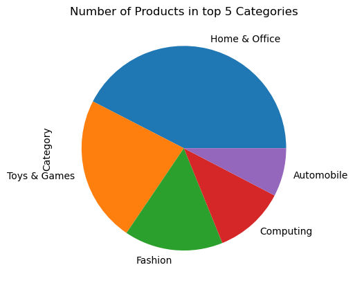

```python
#Plotting the 5 categories
clean_data['Category'].value_counts()[:5].plot(kind='pie').set_title("Number of Products in top 5 Categories")
```

**Q4. What 5 categories have the least number of items on offer?**

This research question aims to identify the five categories with the lowest number of items available in Jumia's offers. By analyzing the dataset, we will determine the frequency of each product category and identify the categories with the least representation in the offers. This information will provide insights into niche or less popular product categories that receive minimal emphasis in Jumia's promotional offers.

```python
clean_data['Category'].value_counts(ascending=True)[:5]
```

```
Books, Movies and Music    1
Grocery                    2
Pet Supplies               3
Garden & Outdoors          5
Baby Products              9
Name: Category, dtype: int64
```

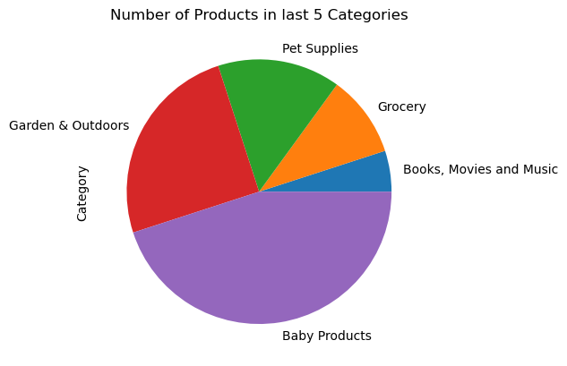

```python
# Plotting the 5 last categories
clean_data['Category'].value_counts(ascending=True)[:5].plot(kind='pie').set_title("Number of Products in last 5 Categories")
```

**Q5. What is the minimum, maximum, average, and standard deviation of offer prices?**

This research question aims to determine the statistical measures of offer prices in the dataset. By analyzing the data, we will calculate the minimum, maximum, average, and standard deviation of the prices. These measures will provide insights into the range and distribution of offer prices, allowing us to understand the variability and central tendency of the pricing structure in Jumia's offers.

```python
clean_data[['Price','Offer']].describe()
```

|  | Price | Offer |
| --- | --- | --- |
| count | 793.000000 | 793.000000 |
| mean | 5125.515763 | 3342.276166 |
| std | 2935.105072 | 1758.834962 |
| min | 125.000000 | 73.000000 |
| 25% | 2835.000000 | 1993.000000 |
| 50% | 4590.000000 | 2940.000000 |
| 75% | 6879.000000 | 4205.000000 |
| max | 15450.000000 | 11100.000000 |

**Q6. How many products have the maximum and minimum discounts?**

This research question aims to determine the number of products that have the maximum and minimum discounts in the dataset. By analyzing the discount values, we will identify the products with the highest and lowest discount percentages. Understanding the count of products with these extreme discounts will provide insights into the distribution of discount levels and the prevalence of significant price reductions among Jumia's offers.

```python
max_discount=clean_data[clean_data['Discount']==clean_data['Discount'].max()]['Name'].count()
discount=clean_data['Discount'].max()
print(f'maximum discount: {discount}%\nNumber of products: {max_discount}')
```

```
maximum discount: 50%
Number of products: 33
```

```python
min_discount=clean_data[clean_data['Discount']==clean_data['Discount'].min()]['Name'].count()
minimumd=clean_data['Discount'].min()
print(f'minimum discount: {minimumd}%\nNumber of products: {min_discount}')
```

```
minimum discount: 4%
Number of products: 1
```

**Q7. Plot for the distribution of discounts. Is it normally distributed?**

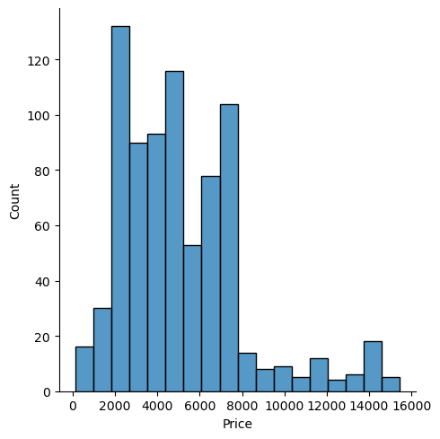

```python
seaborn.displot(data=clean_data['Price'])
```

```python
clean_data['Price'].mean()
```

```
5125.515762925599
```

**Q8a. What is the value of all products on offer?**

This research question aims to determine the total value of all products that are currently on offer in the dataset. By summing up the prices of all the products, we can calculate the overall value of the offers available on Jumia. This information provides an understanding of the cumulative monetary worth of the products and highlights the potential savings or discounts customers can benefit from when purchasing items from the offers.

```python
clean_data['Price'].sum()
```

```
4064534.0
```

**Q8b. What is the value of products in their given categories?**

This research question aims to determine the value of products within their respective categories. By grouping the products based on their categories and summing up the prices within each category, we can calculate the total value of products in each category. This information provides insights into the distribution of value across different product categories and helps identify categories that contribute significantly to the overall value of products on offer.

```python
clean_data.groupby('Category').sum(numeric_only=True)['Price']
```

```
Category
Automobile                  179333.0
Baby Products                35700.0
Books, Movies and Music       3547.0
Computing                   387556.0
Electronics                 122299.0
Fashion                     730877.0
Garden & Outdoors            44387.0
Grocery                       4043.0
Health & Beauty             129817.0
Home & Office              1470751.0
Industrial & Scientific     183245.0
Pet Supplies                 12641.0
Phones & Tablets            130361.0
Services                     64325.0
Sporting Goods              132167.0
Toys & Games                433485.0
Name: Price, dtype: float64
```

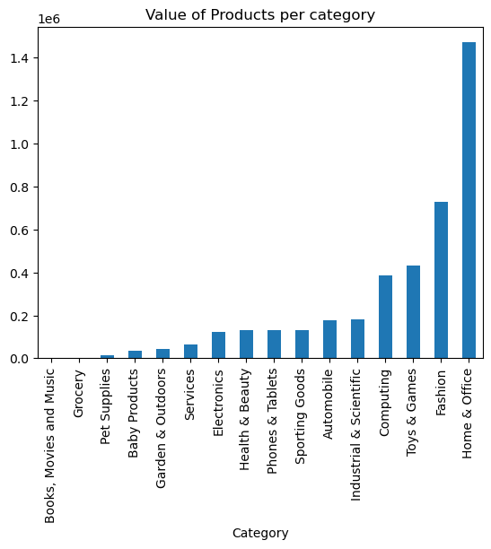

```python
clean_data.groupby('Category').sum(numeric_only=True)['Price'].sort_values().plot(kind='bar').set_title("Value of Products per category")
```

Now that we have explored our data to understand the relationship between its variables, we can proceed to build a linear regression model to predict the price at which Jumia will sell a product on offer based on its selling price.

To build our model, we will follow the following steps:

1. Define the Dependent and Independent Variables:
   - Dependent Variable: The offer price of the product, which we will refer to as 'Offer'.
   - Independent Variable: The selling price of the product, which we will refer to as 'Price'.
2. Split the Data: We will split our data into training and test datasets to assess the model's performance. The training dataset will be used to train the model, while the test dataset will be used to evaluate the model's predictions. This step helps us understand how well the model performs on unseen data.
3. Fit the Model to the Data: Using the training dataset, we will fit a linear regression model to the data. The model will learn the relationship between the selling price and the offer price, allowing us to make predictions based on this relationship.
4. Use the Model for Prediction: Once the model is trained, we can use it to make predictions on new data. In this case, we can use the model to predict the offer price of products based on their selling prices.
5. Evaluate the Performance of the Model: We will assess the performance of our model by evaluating its predictions on the test dataset. Common evaluation metrics for linear regression models include mean squared error (MSE), root mean squared error (RMSE), and R-squared (coefficient of determination). These metrics provide insights into how well the model fits the data and how accurately it predicts the offer price based on the selling price.
6. Obtain Coefficients: As part of the linear regression model, we can obtain the coefficients associated with the independent variable (selling price). These coefficients provide information about the strength and direction of the relationship between the independent and dependent variables. They can help us understand the impact of the selling price on the offer price.

By following these steps, we can build a linear regression model to predict the offer price of products on Jumia based on their selling prices. This model can assist in pricing decisions and provide insights into the relationship between the two variables.

```python
# Defining our dependent(y) and independent(x) variables.
x=df[df.columns[-3:-2]]
y=df[df.columns[-2:-1]]
```

```python
# Slitting our data into train and test
from sklearn.model_selection import train_test_split

x_train,x_test,y_train,y_test=train_test_split(x,y,train_size=0.70)
```

```python
# fitting our model
from sklearn.linear_model import LinearRegression
lmodel=LinearRegression()
lmodel.fit(X=x_train,y=y_train)
```

```
LinearRegression()
```

```python
# Obtaining predictions from our model
pred=lmodel.predict(x_test)
print(len(pred),len(x_test))
```

```
502 502
```

```python
# Evaluating the performance of our model

from sklearn import metrics

mae=round(metrics.mean_absolute_error(y_test,pred),2)
mse=round(metrics.mean_squared_error(y_test,pred),2)
msrte=round(np.sqrt(mse),2)
r_value=round(metrics.explained_variance_score(y_test,pred),4)

print(f'Mean Absolute Error: {mae}\nMean Squared Error: {mse}\nMean Square root Error: {msrte}\nr_value: {r_value}')
```

```
Mean Absolute Error: 325.74
Mean Squared Error: 298554.78
Mean Square root Error: 546.4
r_value: 0.9094
```

These loss functions and evaluation metrics provide insights into the performance of my linear regression model, helping me assess its accuracy in predicting offer prices based on selling prices. Lower values of MAE, MSE, and RMSE and higher values of R-squared generally indicate better model performance, suggesting smaller deviation from the true offer prices and a higher proportion of explained variance.

```python
# Obtaining Coefficients

coeff=lmodel.coef_
print(round(coeff[0][0],3))
```

```
0.557
```

It's important to note that the coefficient alone does not provide information about the statistical significance or the practical significance of the relationship. Further analysis, such as hypothesis testing and considering the context of the problem, would be necessary to interpret the coefficient more comprehensively.

To calculate the offer price given the price of a product and the coefficient, we can use the formula for linear regression:

Offer Price = Intercept + Coefficient * Price

The coefficient represents the slope of the linear regression line, indicating the change in the offer price for each unit change in the price of the product. The intercept represents the point where the regression line intersects the y-axis.

The intercept value would depend on the specific model we have built and would need to be provided or obtained from the model's output.

By plugging in the values and performing the calculation, we can determine the predicted offer price based on the given price of the product.